# Población de mascotas en algunos países

2021-05-25

En esta ocasión exploramos los datos de la población de mascotas que se encuentran disponibles para algunos países en la página de [Knoema](https://knoema.com/data/pets-population+birds)

Los datos tienen registro de la población de mascotas que incluye solo a perros, gatos, peces y aves, correspondientes a 29 países. En este caso para México no hay datos disponibles.

Cuando tenemos datos de poblaciones, en este caso de mascotas, una manera de visualizar estos datos es mediante el uso de proporciones, por ejemplo, de todas las mascotas de China ¿Cuántos son perros o gatos?. Para representar estas proporciones, en esta ocasión utilizamos la visualización *Waffle chart* (por la paquetería `waffe`) el cual muestra un progreso a un objetivo o la completación de un porcentaje. En estos gráficos se forma una cuadricula y cada celda se puede representar de un color hasta llenar una proporción de una categoría.

Por ejemplo, usemos los datos de mascotas para **Rusia**.

| Country | Population | Pets | ByMillon |
| --- | --- | --- | --- |
| Russian Federation | 17800000 | Cats | 17.80 |
| Russian Federation | 12520000 | Dogs | 12.52 |
| Russian Federation | 770000 | Fish | 0.77 |
| Russian Federation | 2800000 | Birds | 2.80 |

De toda su población de mascotas, podemos ver que la categoría **Gatos** es ligeramente más abundante que **Perros**.

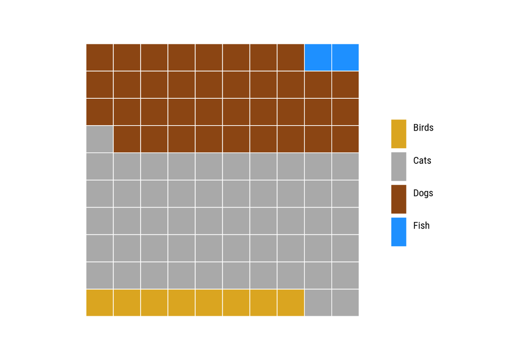

¿Y qué pasa en el caso de otros países? Aquí se muestran los **Waffle charts** de otros países donde resulta peculiar el caso de Brasil, ya que es un país que la mayoría de su población de mascotas esta representada por aves.

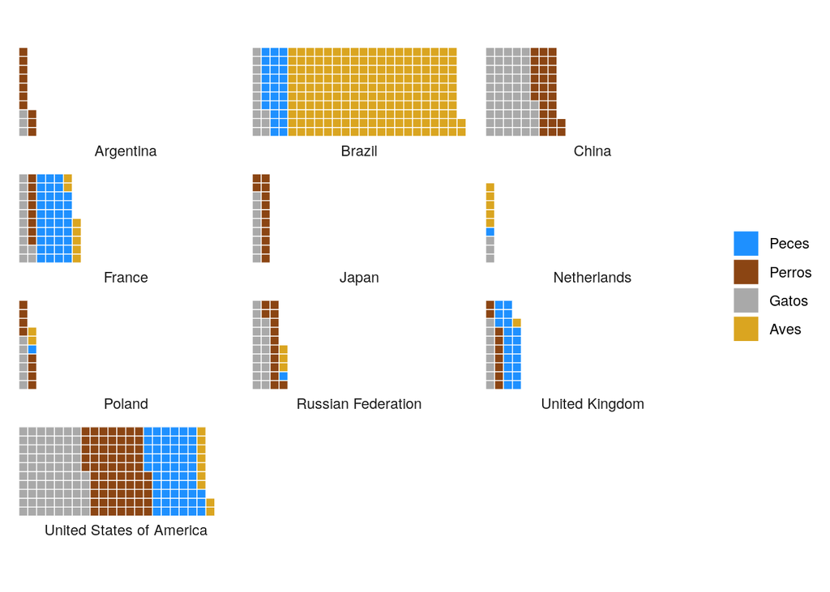

Aprovechando este tipo de gráfico podemos utilizar **pictogramas**, en el cual sustituimos los recuadros por iconos que reflejen al objeto o categoría, en este caso, a las mascotas. Con este ajuste podemos ver ahora como cambian estas visualizaciones en datos de distintos países.

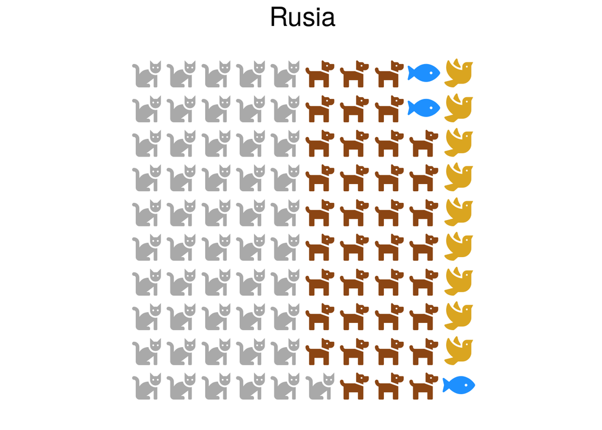

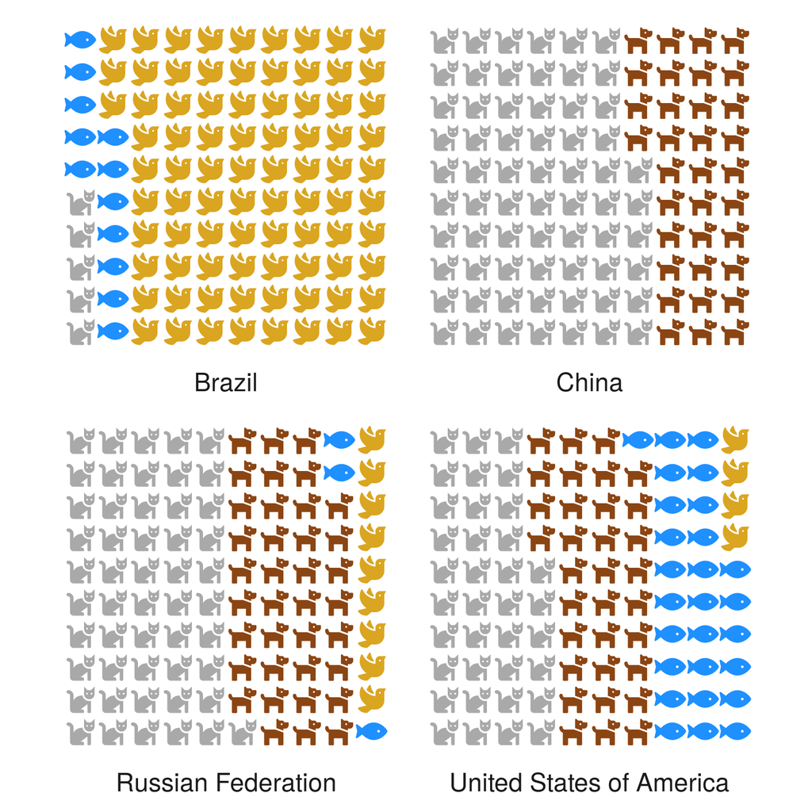